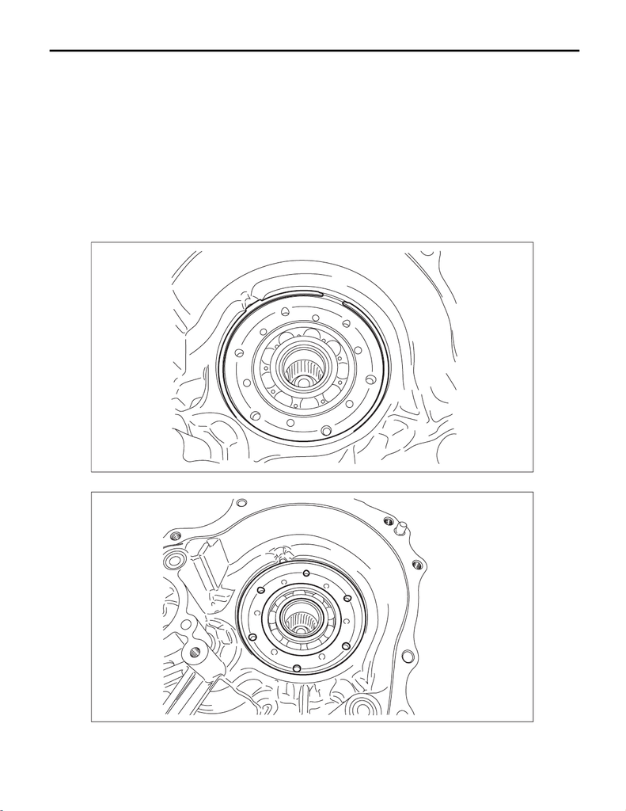

CVT(TR690)-201

Reduction Driven Gear

CONTINUOUSLY VARIABLE TRANSMISSION

38.Reduction Driven Gear

A: REMOVAL

1) Remove the transmission from the vehicle. <Ref. to CVT(TR690)-56, REMOVAL, Automatic Transmission

Assembly.>

2) Remove the extension case. <Ref. to CVT(TR690)-142, REMOVAL, Extension Case.>

3) Remove the rear drive shaft. <Ref. to CVT(TR690)-146, REMOVAL, Rear Drive Shaft.>

4) Remove the transfer clutch assembly. <Ref. to CVT(TR690)-151, REMOVAL, Transfer Clutch.>

5) Remove the center differential carrier. <Ref. to CVT(TR690)-154, REMOVAL, Center Differential Carrier.>

6) Remove the transfer reduction driven gear assembly. <Ref. to CVT(TR690)-158, REMOVAL, Transfer Re-

duction Driven Gear.>

7) Remove the intermediate case. <Ref. to CVT(TR690)-165, REMOVAL, Intermediate Case.>

8) Remove the forward clutch assembly. <Ref. to CVT(TR690)-181, REMOVAL, Forward Clutch Assembly.>

9) Remove the snap ring.

10) Remove the reduction driven gear assembly.

AT-05265

AT-05266

15WRX_STI_US_EN.book 201 ページ ２０１５年２月１３日 金曜日 午前１１時２０分

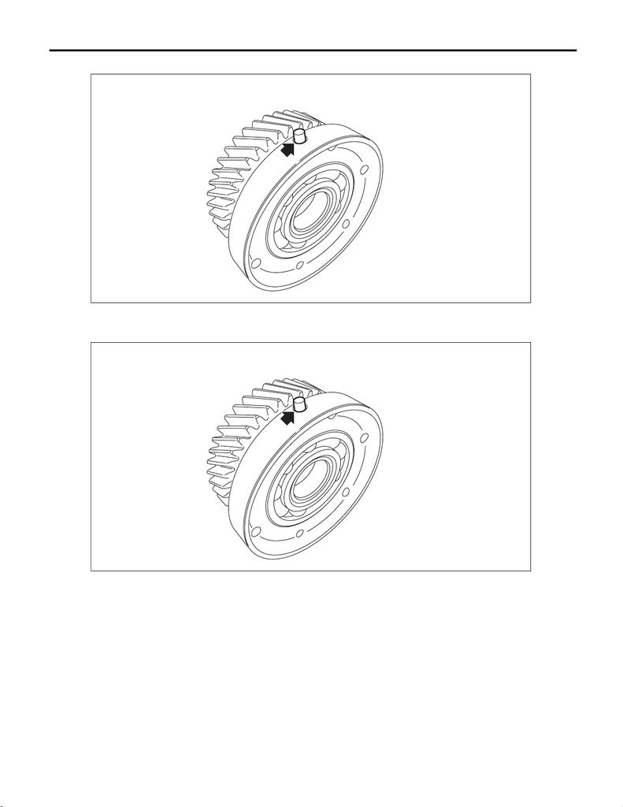

CVT(TR690)-202

Reduction Driven Gear

CONTINUOUSLY VARIABLE TRANSMISSION

11) Remove the straight pin.

B: INSTALLATION

1) Install the straight pin to reduction driven gear assembly.

AT-05267

AT-05267

15WRX_STI_US_EN.book 202 ページ ２０１５年２月１３日 金曜日 午前１１時２０分

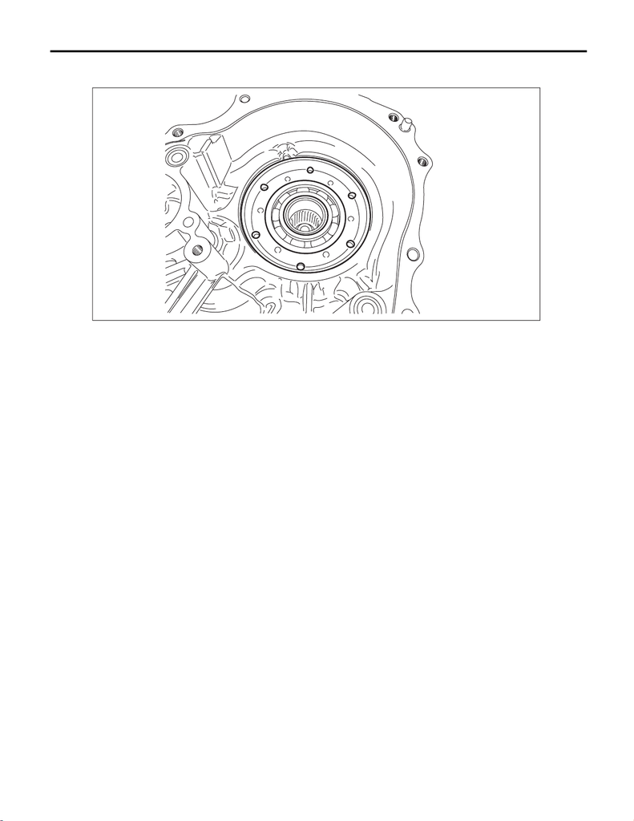

CVT(TR690)-203

Reduction Driven Gear

CONTINUOUSLY VARIABLE TRANSMISSION

2) Fit the straight pin portion to the recess portion of transmission case and install the reduction driven gear

and install the snap ring.

3) Select the snap ring. <Ref. to CVT(TR690)-207, ADJUSTMENT, Reduction Driven Gear.>

4) Replace with the selected snap ring.

NOTE:

If the clearance measured in step 3) is within standard, the snap ring replacement is not necessary.

5) Install the forward clutch assembly. <Ref. to CVT(TR690)-182, INSTALLATION, Forward Clutch Assem-

bly.>

6) Install the intermediate case. <Ref. to CVT(TR690)-166, INSTALLATION, Intermediate Case.>

7) Install the transfer reduction driven gear assembly. <Ref. to CVT(TR690)-158, INSTALLATION, Transfer

Reduction Driven Gear.>

8) Install the center differential carrier. <Ref. to CVT(TR690)-155, INSTALLATION, Center Differential Car-

rier.>

9) Install the transfer clutch assembly. <Ref. to CVT(TR690)-151, INSTALLATION, Transfer Clutch.>

10) Install the rear drive shaft. <Ref. to CVT(TR690)-146, INSTALLATION, Rear Drive Shaft.>

11) Install the extension case. <Ref. to CVT(TR690)-143, INSTALLATION, Extension Case.>

12) Install the transmission to vehicle. <Ref. to CVT(TR690)-69, INSTALLATION, Automatic Transmission

Assembly.>

AT-05266

15WRX_STI_US_EN.book 203 ページ ２０１５年２月１３日 金曜日 午前１１時２０分

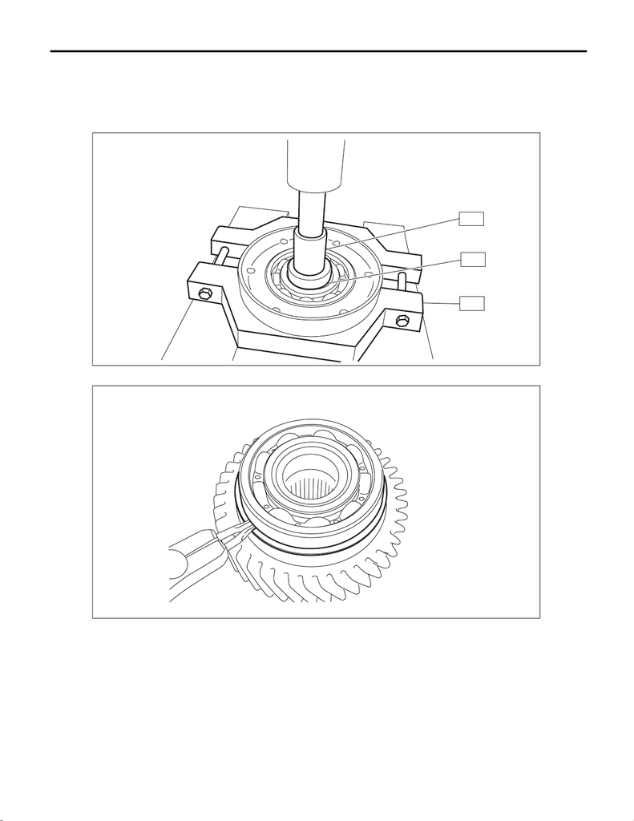

CVT(TR690)-204

Reduction Driven Gear

CONTINUOUSLY VARIABLE TRANSMISSION

C: DISASSEMBLY

1) Remove the bearing retainer using ST1, ST2 and ST3.

ST1 899864100 REMOVER

ST2 398497701 SEAT

ST3 18767AA000 BEARING REMOVER

2) Remove the snap ring.

AT-05268

ST1

ST2

ST3

AT-05269

15WRX_STI_US_EN.book 204 ページ ２０１５年２月１３日 金曜日 午前１１時２０分

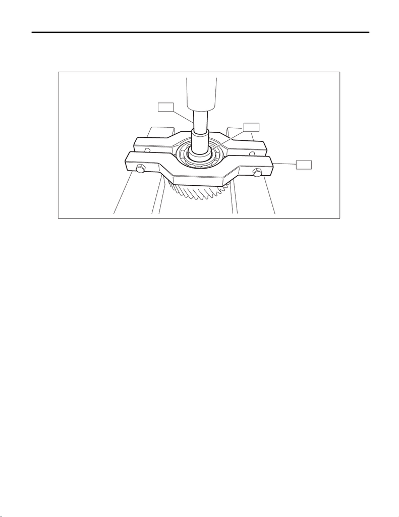

CVT(TR690)-205

Reduction Driven Gear

CONTINUOUSLY VARIABLE TRANSMISSION

3) Remove the ball bearing using ST1, ST2 and ST3.

ST1 899864100 REMOVER

ST2 398497701 SEAT

ST3 498077600 REMOVER

AT-05270

ST1

ST2

ST3

15WRX_STI_US_EN.book 205 ページ ２０１５年２月１３日 金曜日 午前１１時２０分

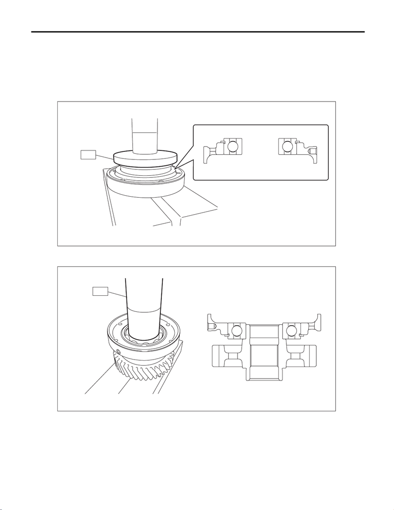

CVT(TR690)-206

Reduction Driven Gear

CONTINUOUSLY VARIABLE TRANSMISSION

D: ASSEMBLY

1) Using the ST, install the ball bearing to bearing retainer.

ST 398177700 INSTALLER

NOTE:

• Use a new ball bearing.

• Make sure to install the ball bearing in the right direction.

• Apply CVTF to the press-fitting area.

2) Using the ST, install the reduction driven gear.

ST 499277200 INSTALLER

E: INSPECTION

• Check the ball bearing for smooth rotation.

• Check the ball bearing for excessive looseness.

• Check the reduction driven gear for breakage or damage.

• Check the clearance between snap ring and transmission case and replace the snap ring as necessary.

AT-05271

ST

AT-05272

ST

15WRX_STI_US_EN.book 206 ページ ２０１５年２月１３日 金曜日 午前１１時２０分

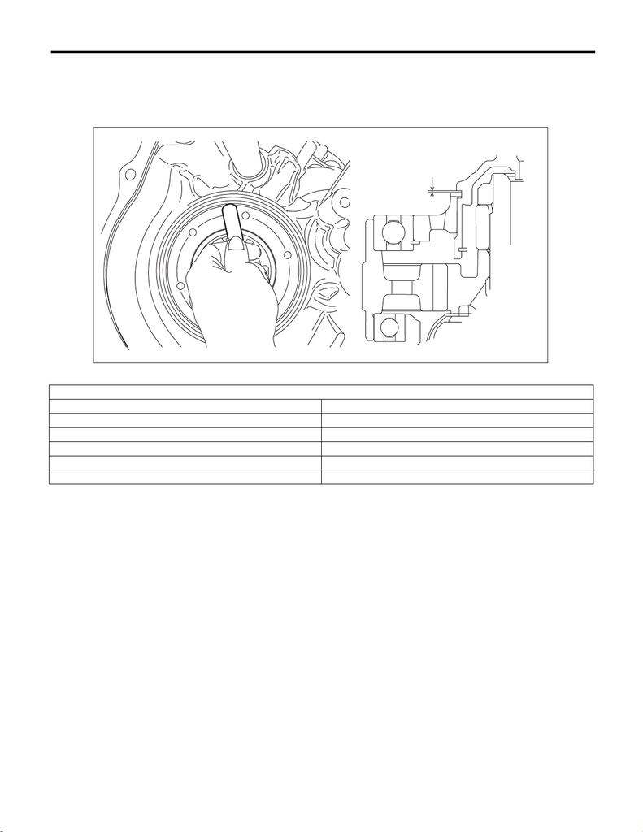

CVT(TR690)-207

Reduction Driven Gear

CONTINUOUSLY VARIABLE TRANSMISSION

F: ADJUSTMENT

1) Measure clearance “A” between snap ring and transmission case.

Specification:

0.05 — 0.25 mm (0.002 — 0.01 in)

2) If clearance “A” is out of standard, select the snap ring within standard.

Snap ring

Part No. Thickness mm (in)

805100460 2.0 (0.079)

805100461 2.1 (0.083)

805100462 2.2 (0.087)

805100463 2.3 (0.091)

805100464 2.4 (0.094)

AT-07889

A

15WRX_STI_US_EN.book 207 ページ ２０１５年２月１３日 金曜日 午前１１時２０分